# R4ds_May3

#### 3.7.1 Exercises

1. What is the default geom associated with stat_summary()? How could you rewrite the previous plot to use that geom function instead of the stat function?

```r
stat_summary()
```

```
## geom_pointrange: na.rm = FALSE
## stat_summary: fun.data = NULL, fun.y = NULL, fun.ymax = NULL, fun.ymin = NULL, fun.args = list(), na.rm = FALSE
## position_identity
```

geom_pointrange is the default geom

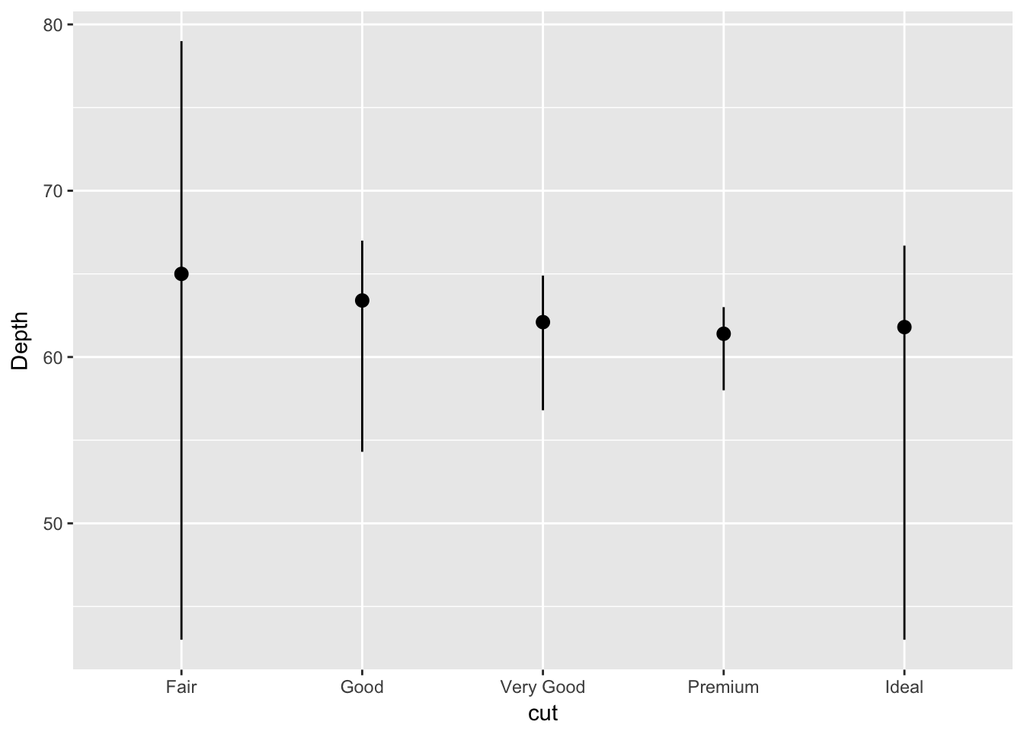

```r
cut=factor(c("Fair", "Good", "Very Good", "Premium", "Ideal"))
depth_median=c(65,63.4,62.1,61.4,61.8)
depth_min=c(43,54.3, 56.8,58,43)
depth_max=c(79,67,64.9,63,66.7)

d<-data.frame(cut,depth_median,depth_min,depth_max)

ggplot(data = d, aes(x=cut, y=depth_median, ymin=depth_min, ymax=depth_max)) + geom_pointrange() + scale_x_discrete(limits=c("Fair","Good","Very Good","Premium","Ideal")) + labs(y="Depth")
```

2. What does geom_col() do? How is it different to geom_bar()?

```r
?geom_col
```

3. Most geoms and stats come in pairs that are almost always used in concert. Read through the documentation and make a list of all the pairs. What do they have in common?

geom_bar, stat_count geom_boxplot, stat_boxplot geom_contour, stat_contour geom_count, stat_sum geom_density, stat_density geom_hex, stat_bin_hex geom_freqpoly, stat_bin geom_qq, stat_qq geom_quantile, stat_quantile geom_smooth, stat_smooth geom_violin, stat_ydensity

They are similar in their mapping arguments.

4. What variables does stat_smooth() compute? What parameters control its behaviour?

```r
?stat_smooth
```

Computed variables: *y predicted value* ymin lower pointwise confidence interval around the mean *ymax upper pointwise confidence interval around the mean* se standard error

Controlled by method, forumla and level

5. In our proportion bar chart, we need to set group = 1. Why? In other words what is the problem with these two graphs?

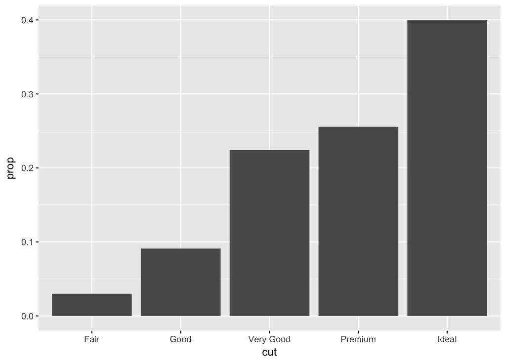

```r
ggplot(data = diamonds) +
  geom_bar(mapping = aes(x = cut, y = ..prop.., group =1))
```

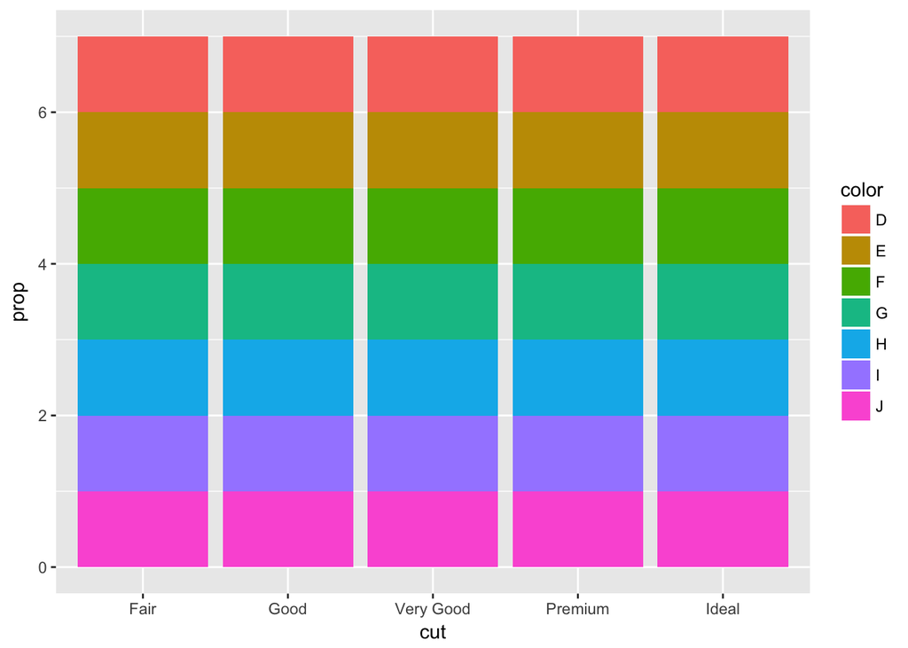

```r
ggplot(data = diamonds) + geom_bar(mapping = aes(x = cut, fill = color, y = ..prop..))
```

The default mapping of group is x (cut in this example) where the number of rows for each level in factor x (e.g. cut) is count separately. Setting group = 1 is to override the default setting so all levels of x are considered together.

#### 3.8 Position adjustments

Can color by fill instead of color

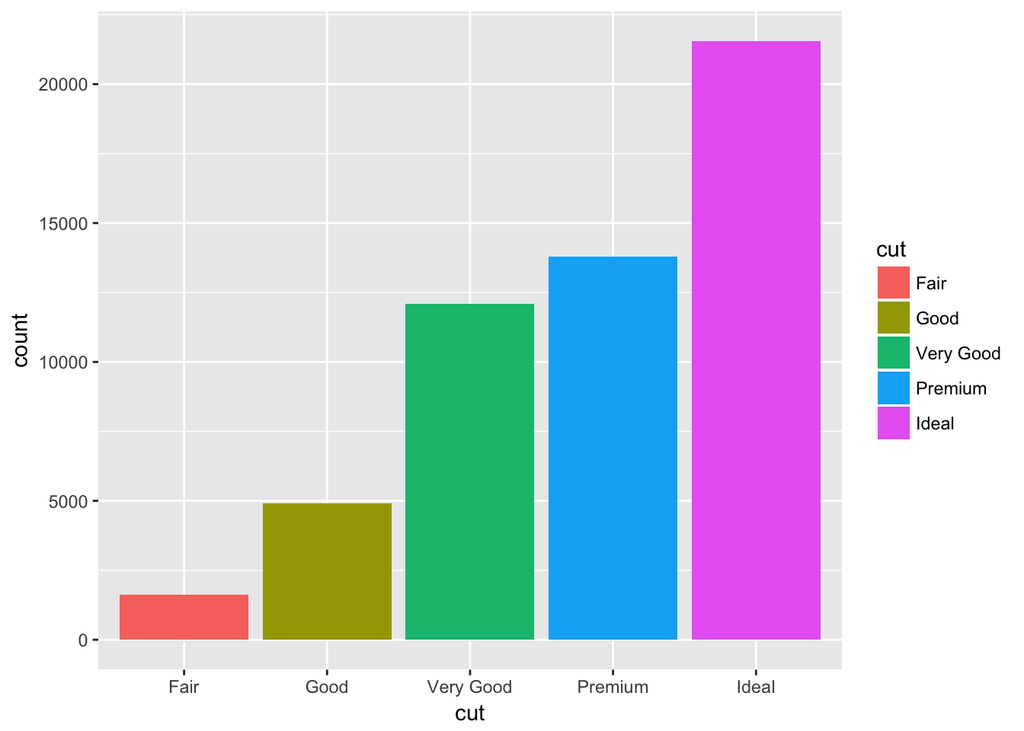

```r
ggplot(data = diamonds) + geom_bar(mapping = aes(x=cut, fill=cut))
```

Can map fill aesthetic to another variable which makes stacked bars

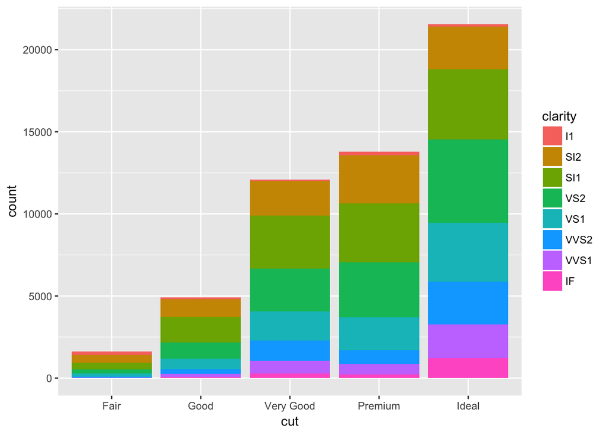

```r
ggplot(data = diamonds) + geom_bar(mapping = aes(x = cut, fill = clarity))
```

Position identity is the actual value of object but overlapping on same bar fill for stacked bars for proportion, each bar adds to 1.0 dodge, objects next to each other

Overplotting, points overlapping, can avoid by “jitter” Less accurate by more revealing

#### 3.8.1 Exercises

1. What is the problem with this plot? How could you improve it?

Overplotting, add jitter

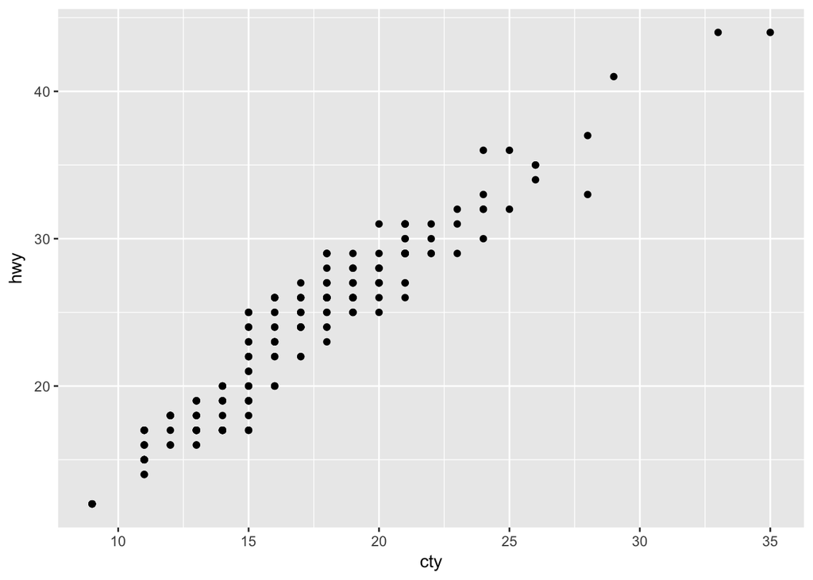

```r
ggplot(data = mpg, mapping = aes(x = cty, y = hwy)) +
  geom_point()
```

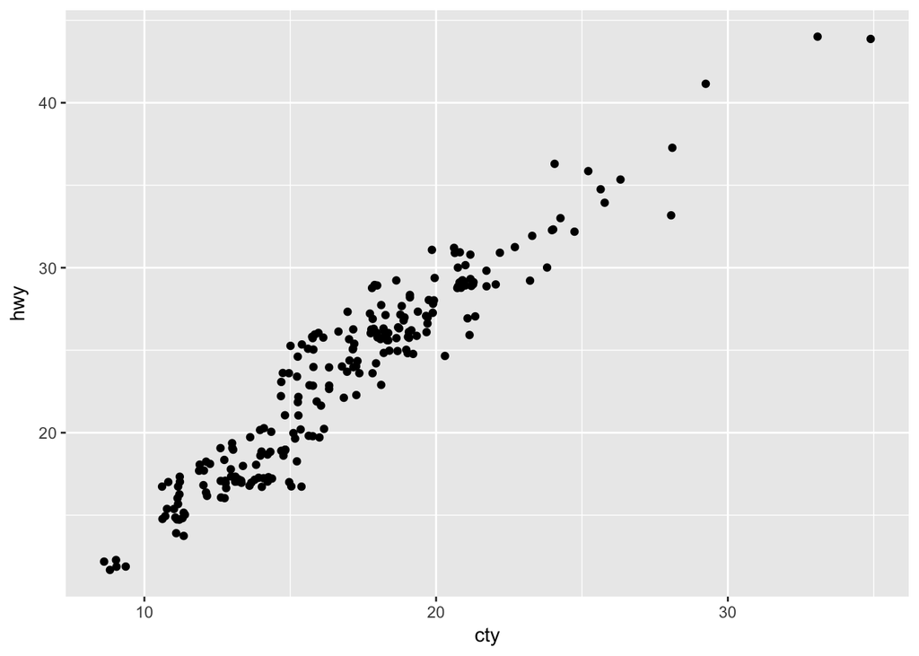

```r
ggplot(data = mpg, mapping = aes(x = cty, y = hwy)) +
  geom_point(position = "jitter")
```

2. What parameters to geom_jitter() control the amount of jittering?

`r ?geom_jitter` width and height default to 40% of the resolution of the data

3. Compare and contrast geom_jitter() with geom_count().

```r
?geom_jitter

?geom_count
```

both variants of geom_point very similar arguments, understands the same aesthetics geom_count position = “identity” vs geom_jitters position = “jitter” jitter random variation in location of each point count maps to point area

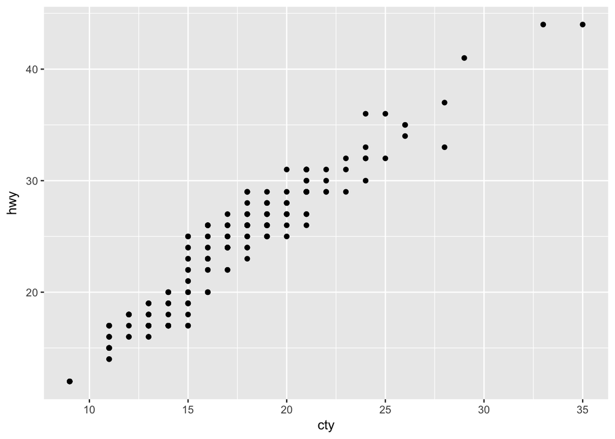

```r
ggplot(mpg, aes(cty, hwy)) +
 geom_point()
```

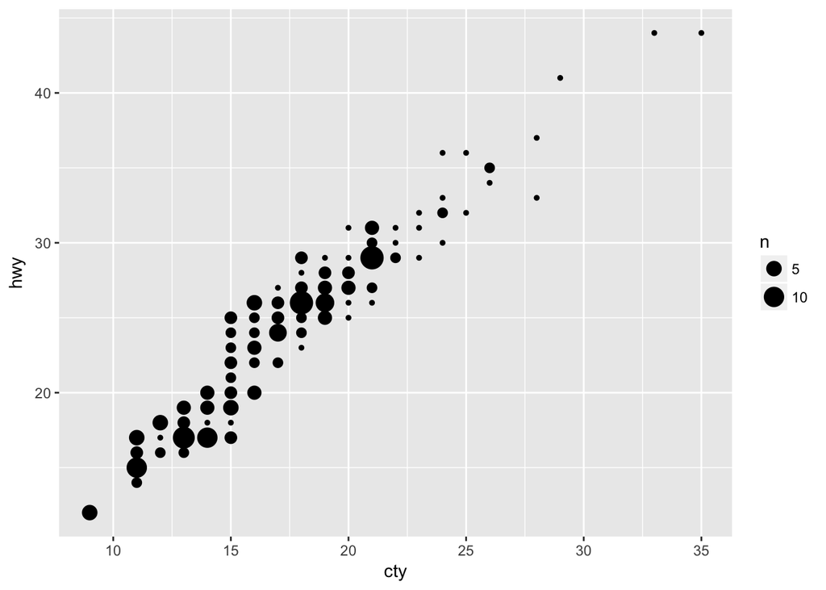

```r
ggplot(mpg, aes(cty, hwy)) +
 geom_count()
```

4. What’s the default position adjustment for geom_boxplot()? Create a visualisation of the mpg dataset that demonstrates it.

default is “dodge”

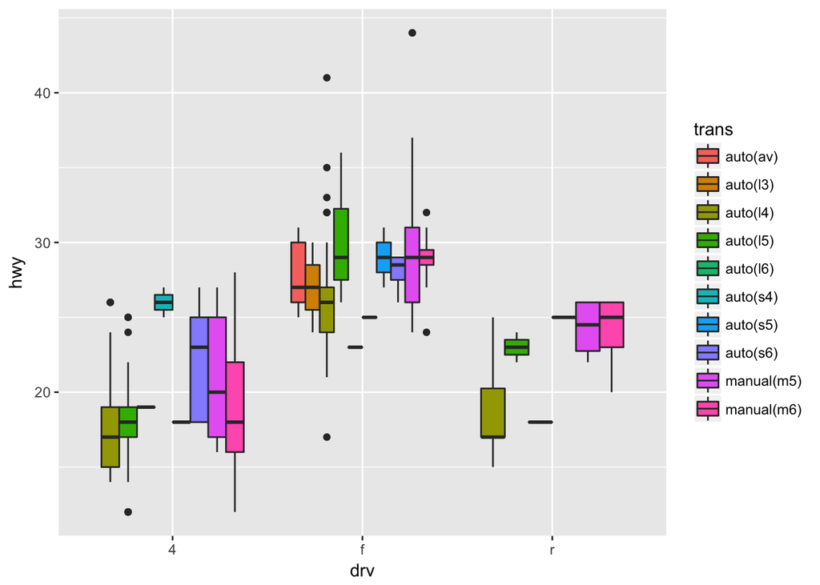

```r
ggplot(mpg, aes(x=drv, y=hwy)) + geom_boxplot(aes(fill=trans))
```

#### 3.9 Coordinate Systems

`coord_flip() switch x and y`